# Artigo Bayesiana

Aishameriane Schmidt

16 de junho de 2017

# Data preparation

## Getting data from IPEA

- Exchange rate R$/US$ (comercial, compra, média do período) Aisha: Ver como traduzir. Obs: inflação já descontada, a taxa está em termos reais.
- IPCA (% a.m) as the inflation index Aisha: Ver como traduzir o “ao mês”
- Unemployment rate (%) for the Metropolitan Regions. Reference period: 30 days.
- SELIC (% a.m., overnight) as the interest rate.

I had to drop several months for all series because the unemployment rate is available only from 2002/03 to 2016/02.

### Exchange rate

```r
# install.packages("lubridate")
library(lubridate)
```

```r
library(ggplot2)
# Lê os dados e armazena numa variável
setwd("C:\\Users\\Aishameriane\\OneDrive\\Documentos\\Mestrado Economia\\Bayesiana - 2017-01\\Materiais artigo\\Dados\\Séries IPEA")
cambio <- read.csv("cambio.csv", sep = ";", dec=",", header=T)

# Limpeza dos dados

# Vê como estão os dados
str(cambio)
```

```
## 'data.frame':    773 obs. of  3 variables:
##  $ ï..Data                                                                                                                                                             : Factor w/ 773 levels "1953.01","1953.02",..: 1 2 3 4 5 6 7 8 9 10 ...
##  $ Taxa.de.cÃ.mbio...R....US....comercial...compra...mÃ.dia...R....Banco.Central.do.Brasil..Boletim..SeÃ.Ã.o.BalanÃ.o.de.Pagamentos..Bacen...Boletim...BP....BM12_ERC12: num  6.68e-15 1.34e-14 1.34e-14 1.49e-14 1.43e-14 ...
##  $ X                                                                                                                                                                   : logi  NA NA NA NA NA NA ...
```

```r
head(cambio)
```

```
##   ï..Data
## 1 1953.01
## 2 1953.02
## 3 1953.03
## 4 1953.04
## 5 1953.05
## 6 1953.06
##   Taxa.de.cÃ.mbio...R....US....comercial...compra...mÃ.dia...R....Banco.Central.do.Brasil..Boletim..SeÃ.Ã.o.BalanÃ.o.de.Pagamentos..Bacen...Boletim...BP....BM12_ERC12
## 1                                                                                                                                                         6.683636e-15
## 2                                                                                                                                                         1.337829e-14
## 3                                                                                                                                                         1.337829e-14
## 4                                                                                                                                                         1.488364e-14
## 5                                                                                                                                                         1.427567e-14
## 6                                                                                                                                                         1.567029e-14
##    X
## 1 NA
## 2 NA
## 3 NA
## 4 NA
## 5 NA
## 6 NA
```

```r
## Muda o nome das colunas e salva apenas as duas primeiras (a terceira está em branco)
colnames(cambio)<-c("data","cambio")
cambio<-cambio[,1:2]

## Adiciona "01" ao fim de todas as datas para poder usar a função do lubridate depois
cambio$data<-paste(cambio$data,".01",sep="")

## Converte o campo para uma data
cambio$data<-ymd(cambio$data)

## Encontra qual linha tem fevereiro de 2002 e fevereiro de 2017
# Observação: período lula: janeiro 2003 a janeiro 2011 e período Dilma: 01 janeiro 2011 a 31 de agosto de 2016
inicio <- which(cambio$data == "2002-03-01")
fim <- which(cambio$data == "2016-02-01")

## Corta os dados
cambio<-cambio[inicio:fim,]

# Verifica como ficaram os dados
str(cambio)
```

```
## 'data.frame':    168 obs. of  2 variables:
##  $ data  : Date, format: "2002-03-01" "2002-04-01" ...
##  $ cambio: num  2.35 2.32 2.48 2.71 2.93 ...
```

```r
head(cambio)
```

```
##           data cambio
## 591 2002-03-01 2.3458
## 592 2002-04-01 2.3196
## 593 2002-05-01 2.4796
## 594 2002-06-01 2.7132
## 595 2002-07-01 2.9338
## 596 2002-08-01 3.1093
```

```r
tail(cambio)
```

```
##           data   cambio
## 753 2015-09-01 3.905810
## 754 2015-10-01 3.879505
## 755 2015-11-01 3.775800
## 756 2015-12-01 3.870495
## 757 2016-01-01 4.051715
## 758 2016-02-01 3.973116
```

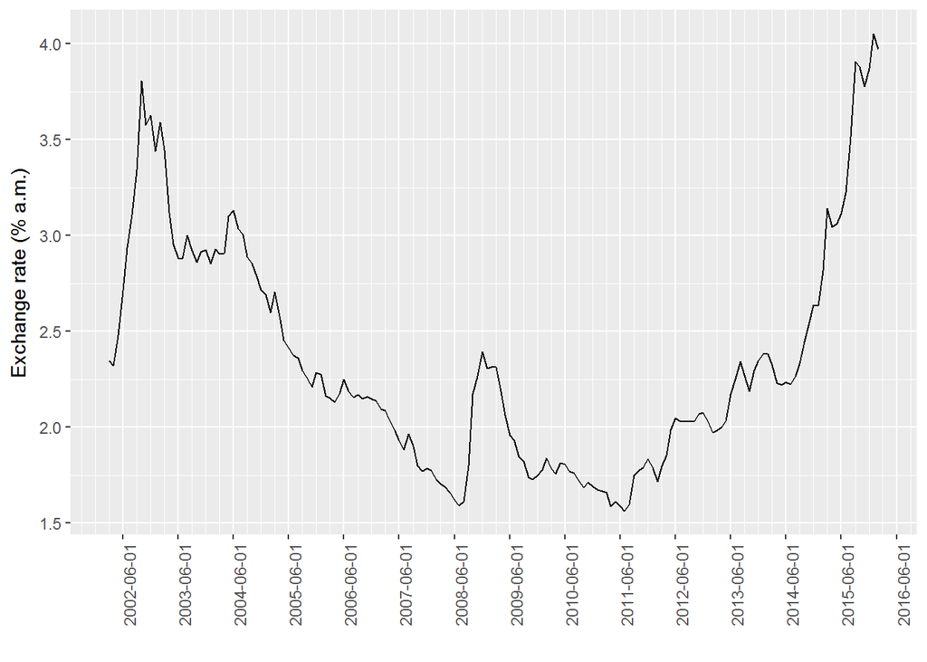

```r
# Plota o gráfico
q <- ggplot(data = cambio, aes(data, cambio)) + geom_line() +
  scale_x_date(limits = c(ymd("2002-03-01"), ymd("2016-02-01")), date_breaks = "12 months", date_minor_breaks = "3 months") + xlab("") + ylab("Exchange rate (% a.m.)")
q + theme(axis.text.x = element_text(angle = 90, hjust = 1))
```

### Inflation

```r
library(lubridate)
library(ggplot2)

# Lê os dados e armazena numa variável
setwd("C:\\Users\\Aishameriane\\OneDrive\\Documentos\\Mestrado Economia\\Bayesiana - 2017-01\\Materiais artigo\\Dados\\Séries IPEA")
inflacao <- read.csv("inflacao.csv", sep = ";", dec=",", header=T)

# Limpeza dos dados

# Vê como estão os dados
str(inflacao)
```

```
## 'data.frame':    449 obs. of  3 variables:
##  $ ï..Data                                                                                                                                                               : Factor w/ 449 levels "1980.01","1980.02",..: 1 2 3 4 5 6 7 8 9 10 ...
##  $ InflaÃ.Ã.o...IPCA......a.m.....Instituto.Brasileiro.de.Geografia.e.EstatÃ.stica..Sistema.Nacional.de.Ã.ndices.de.PreÃ.os.ao.Consumidor..IBGE.SNIPC....PRECOS12_IPCAG12: num  6.62 4.62 6.04 5.29 5.7 ...
##  $ X                                                                                                                                                                     : logi  NA NA NA NA NA NA ...
```

```r
head(inflacao)
```

```
##   ï..Data
## 1 1980.01
## 2 1980.02
## 3 1980.03
## 4 1980.04
## 5 1980.05
## 6 1980.06
##   InflaÃ.Ã.o...IPCA......a.m.....Instituto.Brasileiro.de.Geografia.e.EstatÃ.stica..Sistema.Nacional.de.Ã.ndices.de.PreÃ.os.ao.Consumidor..IBGE.SNIPC....PRECOS12_IPCAG12
## 1                                                                                                                                                               6.615649
## 2                                                                                                                                                               4.616919
## 3                                                                                                                                                               6.038389
## 4                                                                                                                                                               5.286114
## 5                                                                                                                                                               5.702721
## 6                                                                                                                                                               5.305304
##    X
## 1 NA
## 2 NA
## 3 NA
## 4 NA
## 5 NA
## 6 NA
```

```r
## Muda o nome das colunas e salva apenas as duas primeiras (a terceira está em branco)
colnames(inflacao)<-c("data","inflacao")
inflacao<-inflacao[,1:2]

## Adiciona "01" ao fim de todas as datas para poder usar a função do lubridate depois
inflacao$data<-paste(inflacao$data,".01",sep="")

## Converte o campo para uma data
inflacao$data<-ymd(inflacao$data)

## Encontra qual linha tem fevereiro de 2002 e fevereiro de 2017
# Observação: período lula: janeiro 2003 a janeiro 2011 e período Dilma: 01 janeiro 2011 a 31 de agosto de 2016
inicio <- which(inflacao$data == "2002-03-01")
fim <- which(inflacao$data == "2016-02-01")

## Corta os dados
inflacao<-inflacao[inicio:fim,]

# Verifica como ficaram os dados
str(inflacao)
```

```
## 'data.frame':    168 obs. of  2 variables:
##  $ data    : Date, format: "2002-03-01" "2002-04-01" ...
##  $ inflacao: num  0.6 0.8 0.21 0.42 1.19 0.65 0.72 1.31 3.02 2.1 ...
```

```r
head(inflacao)
```

```
##           data inflacao
## 267 2002-03-01     0.60
## 268 2002-04-01     0.80
## 269 2002-05-01     0.21
## 270 2002-06-01     0.42
## 271 2002-07-01     1.19
## 272 2002-08-01     0.65
```

```r
tail(inflacao)
```

```
##           data inflacao
## 429 2015-09-01     0.54
## 430 2015-10-01     0.82
## 431 2015-11-01     1.01
## 432 2015-12-01     0.96
## 433 2016-01-01     1.27
## 434 2016-02-01     0.90
```

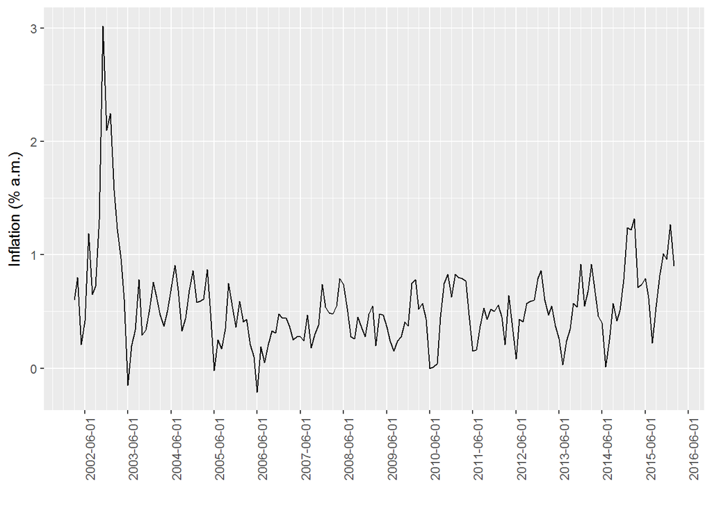

```r
# Plota o gráfico
q <- ggplot(data = inflacao, aes(data, inflacao)) + geom_line() +
  scale_x_date(limits = c(ymd("2002-03-01"), ymd("2016-02-01")), date_breaks = "12 months", date_minor_breaks = "3 months") + xlab("") + ylab("Inflation (% a.m.)")
q + theme(axis.text.x = element_text(angle = 90, hjust = 1))
```

### Interest Rate (Selic)

```r
library(lubridate)
library(ggplot2)

# Lê os dados e armazena numa variável
setwd("C:\\Users\\Aishameriane\\OneDrive\\Documentos\\Mestrado Economia\\Bayesiana - 2017-01\\Materiais artigo\\Dados\\Séries IPEA")
juros <- read.csv("juros.csv", sep = ";", dec=",", header=T)

# Limpeza dos dados

# Vê como estão os dados
str(juros)
```

```
## 'data.frame':    521 obs. of  3 variables:
##  $ ï..Data                                                                                                                                                       : Factor w/ 521 levels "1974.01","1974.02",..: 1 2 3 4 5 6 7 8 9 10 ...
##  $ Taxa.de.juros...Over...Selic......a.m.....Banco.Central.do.Brasil..Boletim..SeÃ.Ã.o.mercado.financeiro.e.de.capitais..Bacen.Boletim.M..Finan.....BM12_TJOVER12: num  1.46 1.15 1.16 1.21 1.24 1.51 1.62 1 1.38 1.12 ...
##  $ X                                                                                                                                                             : logi  NA NA NA NA NA NA ...
```

```r
head(juros)
```

```
##   ï..Data
## 1 1974.01
## 2 1974.02
## 3 1974.03
## 4 1974.04
## 5 1974.05
## 6 1974.06
##   Taxa.de.juros...Over...Selic......a.m.....Banco.Central.do.Brasil..Boletim..SeÃ.Ã.o.mercado.financeiro.e.de.capitais..Bacen.Boletim.M..Finan.....BM12_TJOVER12
## 1                                                                                                                                                           1.46
## 2                                                                                                                                                           1.15
## 3                                                                                                                                                           1.16
## 4                                                                                                                                                           1.21
## 5                                                                                                                                                           1.24
## 6                                                                                                                                                           1.51
##    X
## 1 NA
## 2 NA
## 3 NA
## 4 NA
## 5 NA
## 6 NA
```

```r
## Muda o nome das colunas e salva apenas as duas primeiras (a terceira está em branco)
colnames(juros)<-c("data","juros")
juros<-juros[,1:2]

## Adiciona "01" ao fim de todas as datas para poder usar a função do lubridate depois
juros$data<-paste(juros$data,".01",sep="")

## Converte o campo para uma data
juros$data<-ymd(juros$data)

## Encontra qual linha tem fevereiro de 2002 e fevereiro de 2017
# Observação: período lula: janeiro 2003 a janeiro 2011 e período Dilma: 01 janeiro 2011 a 31 de agosto de 2016
inicio <- which(juros$data == "2002-03-01")
fim <- which(juros$data == "2016-02-01")

## Corta os dados
juros<-juros[inicio:fim,]

# Verifica como ficaram os dados
str(juros)
```

```
## 'data.frame':    168 obs. of  2 variables:
##  $ data : Date, format: "2002-03-01" "2002-04-01" ...
##  $ juros: num  1.37 1.48 1.41 1.33 1.54 ...
```

```r
head(juros)
```

```
##           data    juros
## 339 2002-03-01 1.371333
## 340 2002-04-01 1.483567
## 341 2002-05-01 1.414989
## 342 2002-06-01 1.329033
## 343 2002-07-01 1.535435
## 344 2002-08-01 1.443404
```

```r
tail(juros)
```

```
##           data    juros
## 501 2015-09-01 1.108964
## 502 2015-10-01 1.108964
## 503 2015-11-01 1.055878
## 504 2015-12-01 1.162077
## 505 2016-01-01 1.055878
## 506 2016-02-01 1.002820
```

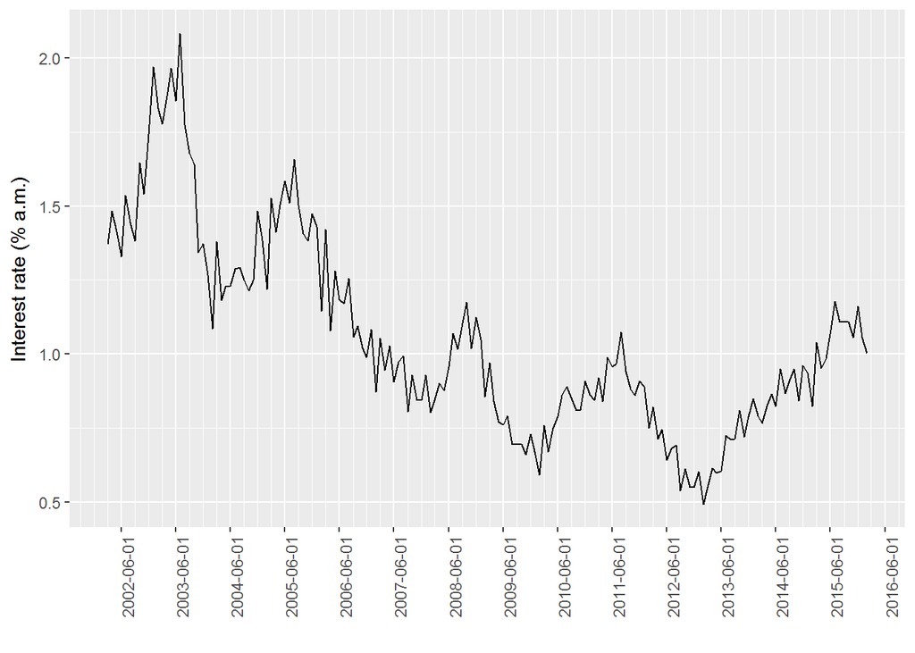

```r
# Plota o gráfico
q <- ggplot(data = juros, aes(data, juros)) + geom_line() +
  scale_x_date(limits = c(ymd("2002-03-01"), ymd("2016-02-01")), date_breaks = "12 months", date_minor_breaks = "3 months") + xlab("") + ylab("Interest rate (% a.m.)")
q + theme(axis.text.x = element_text(angle = 90, hjust = 1))
```

### Unemployment rate

```r
library(lubridate)
library(ggplot2)

# Lê os dados e armazena numa variável
setwd("C:\\Users\\Aishameriane\\OneDrive\\Documentos\\Mestrado Economia\\Bayesiana - 2017-01\\Materiais artigo\\Dados\\Séries IPEA")
desemprego <- read.csv("desemprego.csv", sep = ";", dec=",", header=T)

# Limpeza dos dados

# Vê como estão os dados
str(desemprego)
```

```
## 'data.frame':    168 obs. of  3 variables:
##  $ ï..Data                                                                                                                                                      : Factor w/ 168 levels "2002.03","2002.04",..: 1 2 3 4 5 6 7 8 9 10 ...
##  $ Taxa.de.desemprego...referÃªncia..30.dias...RMs.........Instituto.Brasileiro.de.Geografia.e.EstatÃ.stica..Pesquisa.Mensal.de.Emprego..IBGE.PME....PMEN12_TD12: num  12.9 12.5 11.9 11.6 11.9 11.7 11.5 11.2 10.9 10.5 ...
##  $ X                                                                                                                                                            : logi  NA NA NA NA NA NA ...
```

```r
head(desemprego)
```

```
##   ï..Data
## 1 2002.03
## 2 2002.04
## 3 2002.05
## 4 2002.06
## 5 2002.07
## 6 2002.08
##   Taxa.de.desemprego...referÃªncia..30.dias...RMs.........Instituto.Brasileiro.de.Geografia.e.EstatÃ.stica..Pesquisa.Mensal.de.Emprego..IBGE.PME....PMEN12_TD12
## 1                                                                                                                                                          12.9
## 2                                                                                                                                                          12.5
## 3                                                                                                                                                          11.9
## 4                                                                                                                                                          11.6
## 5                                                                                                                                                          11.9
## 6                                                                                                                                                          11.7
##    X
## 1 NA
## 2 NA
## 3 NA
## 4 NA
## 5 NA
## 6 NA
```

```r
## Muda o nome das colunas e salva apenas as duas primeiras (a terceira está em branco)
colnames(desemprego)<-c("data","desemprego")
desemprego<-desemprego[,1:2]

## Adiciona "01" ao fim de todas as datas para poder usar a função do lubridate depois
desemprego$data<-paste(desemprego$data,".01",sep="")

## Converte o campo para uma data
desemprego$data<-ymd(desemprego$data)

## Encontra qual linha tem fevereiro de 2002 e fevereiro de 2017
# Observação: período lula: janeiro 2003 a janeiro 2011 e período Dilma: 01 janeiro 2011 a 31 de agosto de 2016
inicio <- which(desemprego$data == "2002-03-01")
fim <- which(desemprego$data == "2016-02-01")

## Corta os dados
desemprego<-desemprego[inicio:fim,]

# Verifica como ficaram os dados
str(desemprego)
```

```
## 'data.frame':    168 obs. of  2 variables:
##  $ data      : Date, format: "2002-03-01" "2002-04-01" ...
##  $ desemprego: num  12.9 12.5 11.9 11.6 11.9 11.7 11.5 11.2 10.9 10.5 ...
```

```r
head(desemprego)
```

```
##         data desemprego
## 1 2002-03-01       12.9
## 2 2002-04-01       12.5
## 3 2002-05-01       11.9
## 4 2002-06-01       11.6
## 5 2002-07-01       11.9
## 6 2002-08-01       11.7
```

```r
tail(desemprego)
```

```
##           data desemprego
## 163 2015-09-01        7.5
## 164 2015-10-01        7.8
## 165 2015-11-01        7.5
## 166 2015-12-01        6.9
## 167 2016-01-01        7.6
## 168 2016-02-01        8.2
```

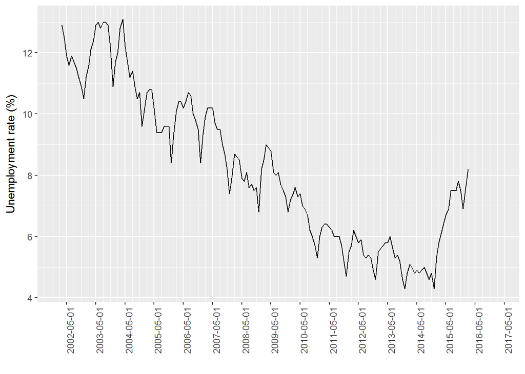

```r
# Plota o gráfico
q <- ggplot(data = desemprego, aes(data, desemprego)) + geom_line() +
  scale_x_date(limits = c(ymd("2002-02-01"), ymd("2017-02-01")), date_breaks = "12 months", date_minor_breaks = "3 months") + xlab("") + ylab("Unemployment rate (%)")
q + theme(axis.text.x = element_text(angle = 90, hjust = 1))
```

## Seasonal adjustment

Useful links about the seasonal package:

- [seas start year error R](https://stackoverflow.com/questions/30361807/seas-start-year-error-r)
- [seasonal website](http://www.seasonal.website/)
- [seasonal help](https://cran.r-project.org/web/packages/seasonal/seasonal.pdf)
- [seasonal and trend decomposition in R](https://anomaly.io/seasonal-trend-decomposition-in-r/)
- [Position scales for date/time in ggplot2](http://ggplot2.tidyverse.org/reference/scale_date.html)
- [Labeling axis of dates in ggplot?](https://stackoverflow.com/questions/39782331/labeling-axis-of-dates-in-ggplot)
- [Seasonal adjustment plots](https://www.rdocumentation.org/packages/seasonal/versions/1.5.1/topics/plot.seas)

*Observation:* There is something strange in the exchange data plot, because it does not have de black line. Dont forget to verify later.

*To-do list:*

- Verify all red topics
- Try to make the plots using ggplot2
- See if Mateus used something different (x11, instead seats, maybe?)

```r
# Ajuste sazonal - todas as séries juntas
## Achei ruim de visualizar
dados<- data.frame(cambio$data, cambio$cambio, juros$juros, inflacao$inflacao, desemprego$desemprego)
colnames(dados)<-c("data", "cambio", "juros", "inflacao", "desemprego")

## install.packages("seasonal")
library(seasonal)
```

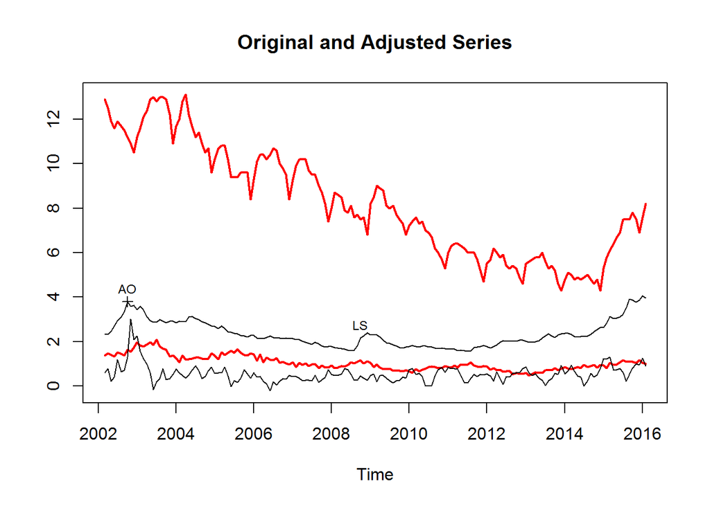

```r
## Cria um objeto do tipo série temporal
dados_seas <- ts(dados[,-1], frequency = 12, start=c(2002,3))
dados_seas2<-seas(dados_seas)
plot(dados_seas2)
```

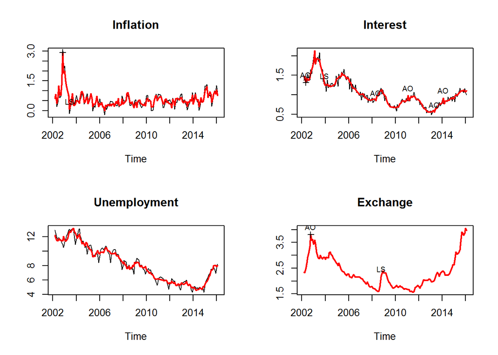

```r
# Ajuste sazonal - séries separadamente

inflacao_seas <- ts(inflacao[,-1], frequency = 12, start=c(2002,3))
inflacao_seas2<-seas(inflacao_seas)

juros_seas <- ts(juros[,-1], frequency = 12, start=c(2002,3))
juros_seas2<-seas(juros_seas)

desemprego_seas <- ts(desemprego[,-1], frequency = 12, start=c(2002,3))
desemprego_seas2<-seas(desemprego_seas)

cambio_seas <- ts(cambio[,-1], frequency = 12, start=c(2002,3))
cambio_seas2<-seas(cambio_seas)

par(mfrow=c(2,2))
plot(inflacao_seas2, main = "Inflation")
plot(juros_seas2, main = "Interest")
plot(desemprego_seas2, main = "Unemployment")
plot(cambio_seas2, main = "Exchange")
```

## Checking with Mateus data

```r
# install.packages("R.matlab")
library(R.matlab)
dados_mateus <- readMat("C:\\Users\\Aishameriane\\OneDrive\\Documentos\\Mestrado Economia\\Bayesiana - 2017-01\\Materiais artigo\\Dados\\DADOS_dessaz.mat")

#head(dados_mateus)
paste(tail(inflacao_seas2$data[,1]), tail(desemprego_seas2$data[,1]), tail(juros_seas2$data[,1]), tail(cambio_seas2$data[,1]))
```

```
## [1] "0.617242706580944 7.50100099792276 1.10084482868539 3.905809524"
## [2] "0.822945194286354 7.97250358786134 1.09773669097347 3.879504762"
## [3] "0.961670330164161 7.99724607261003 1.12806649601003 3.7758"
## [4] "0.832694584050488 8.05808225476267 1.09092368644123 3.870495455"
## [5] "1.04742773637412 7.82103171658556 1.0801671971066 4.051715"
## [6] "0.756722278290724 7.98901868014917 1.11054292210931 3.973115789"
```

```r
paste(head(inflacao_seas2$data[,1]), head(desemprego_seas2$data[,1]), head(juros_seas2$data[,1]), head(cambio_seas2$data[,1]))
```

```
## [1] "0.610791610009525 12.2047475582612 1.44610979187609 2.3458"
## [2] "0.815011375715197 11.8098184755411 1.4689060015935 2.3196"
## [3] "0.373933434786247 11.4531880888719 1.31738994041136 2.4796"
## [4] "0.645185677185941 11.3949183884253 1.43003928539487 2.7132"
## [5] "1.23826033366958 11.7017852928716 1.39415915569408 2.9338"
## [6] "0.781466537038026 11.5251182707081 1.37512989578812 3.1093"
```

## Saving the adjusted data into new variables

```r
inflacao_adj  <-inflacao_seas2$data[,1]
desemprego_adj<-desemprego_seas2$data[,1]
juros_adj     <-juros_seas2$data[,1]
cambio_adj    <-cambio_seas2$data[,1]

dados_adj<-data.frame(cambio$data, inflacao_adj, desemprego_adj, juros_adj, cambio_adj)
colnames(dados_adj)<-c("data", "inflacao", "desemprego", "juros", "cambio")
tail(dados_adj)
```

```
##           data  inflacao desemprego    juros   cambio
## 163 2015-09-01 0.6172427   7.501001 1.100845 3.905810
## 164 2015-10-01 0.8229452   7.972504 1.097737 3.879505
## 165 2015-11-01 0.9616703   7.997246 1.128066 3.775800
## 166 2015-12-01 0.8326946   8.058082 1.090924 3.870495
## 167 2016-01-01 1.0474277   7.821032 1.080167 4.051715
## 168 2016-02-01 0.7567223   7.989019 1.110543 3.973116
```

# Model

The model will be something like this:

$$\begin{bmatrix}
\text{IPCA}_t \\
\text{DES}_t \\
\text{SELIC}_t \\
\text{CAM}_t
\end{bmatrix}
=
\underbrace{
\begin{bmatrix}
\phi^{\text{IPCA}_t}_{0} \\
\phi^{\text{DES}_t}_{0} \\
\phi^{\text{SELIC}_t}_{0} \\
\phi^{\text{CAM}_t}_{0}
\end{bmatrix}}_{B_{(0)C_t}}
+
\underbrace{
\begin{bmatrix}
\phi_{11} & \phi_{12} & \phi_{13} & \phi_{14} \\
\phi_{21} & \phi_{22} & \phi_{23} & \phi_{24} \\
\phi_{31} & \phi_{32} & \phi_{33} & \phi_{34} \\
\phi_{41} & \phi_{42} & \phi_{43} & \phi_{44} \\
\end{bmatrix}
\begin{bmatrix}
\text{IPCA}_{t-1} \\
\text{DES}_{t-1} \\
\text{SELIC}_{t-1} \\
\text{CAM}_{t-1}
\end{bmatrix}}_{BX_t}
+
\mathscr{U}(H_t^{-1})
\begin{bmatrix}
\varepsilon^{\text{IPCA}_t}_{t} \\
\varepsilon^{\text{DES}_t}_{t} \\
\varepsilon^{\text{SELIC}_t}_{t} \\
\varepsilon^{\text{CAM}_t}_{t}
\end{bmatrix}$$

# Establishing the prior

Uhlig’s suggestion is to use a modification of the Minnesota random walk prior:

- $\bar{B_0}$ correspond to a random walk specification;
- $\nu = 60$ (monthly data);
- $\lambda = \frac{\nu}{\nu+1}$;
- $g_0(B)=1$;
- $S_0$ is the diagonal matrix of the average squared residuals from $AR(1)$ univariate regressions for each series;
- There is no need to take log because the series are in per cent;
- It says to include a constant and time trend, I really don’t know where<>

## Running the AR(1) for the data

- [Cookbook](http://www.personal.psu.edu/asb17/old/sta4853/files/sta4853-11print.pdf)

```r
inflacao_ar<-arima(dados_adj$inflacao, order=c(1,0,0))
desemprego_ar<-arima(dados_adj$desemprego, order=c(1,0,0))
juros_ar<-arima(dados_adj$juros, order=c(1,0,0))
cambio_ar<-arima(dados_adj$cambio, order=c(1,0,0))

inflacao_ar_coef<-inflacao_ar$coef[1]
inflacao_ar_coef
```

```
##       ar1
## 0.7138302
```

```r
desemprego_ar_coef<-desemprego_ar$coef[1]
desemprego_ar_coef
```

```
##       ar1
## 0.9946332
```

```r
juros_ar_coef<-juros_ar$coef[1]
juros_ar_coef
```

```
##       ar1
## 0.9808166
```

```r
cambio_ar_coef<-cambio_ar$coef[1]
cambio_ar_coef
```

```
##       ar1
## 0.9914219
```

- For the next step, take a look [here](https://tonyyateshomepage.files.wordpress.com/2014/03/building-to-bayesian-vars.pdf), [here](http://www.kthohr.com/bmr), [here](http://apps.eui.eu/Personal/Canova/Articles/ch10.pdf) and [here](https://www.ecb.europa.eu/pub/pdf/scpwps/ecbwp1494.pdf?7a3b1329a8345a4451700a0cdceb3b46).

Thinking out loud:

- Since I have only one lag, my $B$ matrix have size $4 \times 4$

The elements of $\Sigma_\alpha$ will have the form

Obs: it’s UBAR{V}

$$\begin{equation}\label{eq-6.018}
\bar{V}_{i_{jj}} =
\begin{cases}
\frac{a_1}{r^2} \qquad \text{para coeficientes da própria variável e } r=1, \ldots, p \text{depende do coeficiente ser relativo à defasagem de ordem } r \\
\frac{a_2}{r^2} \frac{\sigma_{ii}}{\sigma_{jj}} \qquad \text{para coeficientes de defasagem } r \text{da variável } j \text{na equação de } i\\
a_3 \sigma_{ii} \qquad \text{para coeficientes de variáveis exógenas.}
\end{cases}
\end{equation}$$

What’s next?

Koop’s code:

## Head

```
%--------------------------------------------------------------------------
% Bayesian estimation, prediction and impulse response analysis in VAR
% models. Dependent on your choice of forecasting, the VAR model is:
%
% Iterated forecasts:
%     Y(t) = A0 + Y(t-1) x A1 + ... + Y(t-p) x Ap + e(t)
%
% so that in this case there are p lags of Y (from 1 to p).
%
% Direct h-step ahead foreacsts:
%     Y(t+h) = A0 + Y(t) x A1 + ... + Y(t-p+1) x Ap + e(t+h)
%
% so that in this case there are also p lags of Y (from 0 to p-1).
%
% In any of the two cases, the model is written as:
%
%                   Y(t) = X(t) x A + e(t)
%
% where e(t) ~ N(0,SIGMA), and A summarizes all parameters. Note that we
% also use the vector a which is defined as a=vec(A).
%
%--------------------------------------------------------------------------
```

# Loading data

```
tic;

%------------------------------LOAD DATA-----------------------------------
% Load Quarterly US data on inflation, unemployment and interest rate,
% 1953:Q1 - 2006:Q3
load Yraw.dat;


% In any case, name the data you load 'Yraw', in order to avoid changing the
% rest of the code. Note that 'Yraw' is a matrix with T rows by M columns,
% where T is the number of time series observations (usually months or
% quarters), while M is the number of VAR dependent macro variables.
```

## Getting ready

- Meu modelo tem intercepto? Qual o significado dele? <>
- Precisa de previsão? Nesse caso tem que separar uma amostra para “conferência”? <>

```
%----------------------------PRELIMINARIES---------------------------------
% Define specification of the VAR model
constant = 1;        % 1: if you desire intercepts, 0: otherwise
p = 2;               % Number of lags on dependent variables
forecasting = 1;     % 1: Compute h-step ahead predictions, 0: no prediction
forecast_method = 0; % 0: Direct forecasts
                     % 1: Iterated forecasts
h = 4;               % Number of forecast periods

% Set prior for BVAR model:
prior = 2;  % prior = 1 --> Noninformative Prior
            % prior = 2 --> Minnesota Prior
            % prior = 3 --> Natural conjugate Prior
```

## Data handling

- Vou precisar de um ou mais lags? Qual a justificativa pra quantidade de lags? Se colocar mais defasagens precisa aumentar a ordem do AR da priori de minnesota?<>

```
%--------------------------DATA HANDLING-----------------------------------
% Get initial dimensions of dependent variable
[Traw M] = size(Yraw);

% The model specification is different when implementing direct forecasts,
% compared to the specification when computing iterated forecasts.
if forecasting==1
    if h<=0
        error('You have set forecasting, but the forecast horizon choice is wrong')
    end

    % Now create VAR specification according to forecast method
    if forecast_method==0       % Direct forecasts
        Y1 = Yraw(h+1:end,:);
        Y2 = Yraw(2:end-h,:);
        Traw = Traw - h - 1;
    elseif forecast_method==1   % Iterated forecasts
        Y1 = Yraw;
        Y2 = Yraw;
    else
        error('Wrong choice of forecast_method')
    end
else
   Y1 = Yraw;
   Y2 = Yraw;
end

% Generate lagged Y matrix. This will be part of the X matrix
Ylag = mlag2(Y2,p); % Y is [T x M]. ylag is [T x (Mp)]

% Now define matrix X which has all the R.H.S. variables (constant, lags of
% the dependent variable and exogenous regressors/dummies)
if constant
    X1 = [ones(Traw-p,1) Ylag(p+1:Traw,:)];
else
    X1 = Ylag(p+1:Traw,:);  %#ok<UNRCH>
end

% Get size of final matrix X
[Traw3 K] = size(X1);

% Create the block diagonal matrix Z
Z1 = kron(eye(M),X1);

% Form Y matrix accordingly
% Delete first "LAGS" rows to match the dimensions of X matrix
Y1 = Y1(p+1:Traw,:); % This is the final Y matrix used for the VAR

% Traw was the dimesnion of the initial data. T is the number of actual
% time series observations of Y and X
T = Traw - p;
```

## Previsão

- Preciso disso?<>

```
%========= FORECASTING SET-UP:
% Now keep also the last "h" or 1 observations to evaluate (pseudo-)forecasts
if forecasting==1
    if forecast_method==0  % Direct forecasts, we only need to keep the
        Y = Y1(1:end-1,:);                             % last observation
        X = X1(1:end-1,:);
        Z = kron(eye(M),X);
        T = T - 1;
    else              % Iterated forecasts, we keep the last h observations
        Y = Y1(1:end-h,:);
        X = X1(1:end-h,:);
        Z = kron(eye(M),X);
        T = T - h;
    end
else
    Y = Y1;
    X = X1;
    Z = Z1;
end
```

## Prioris

```
%--------------------------------PRIORS------------------------------------
% First get Ordinary Least Squares (OLS) estimators
A_OLS = inv(X'*X)*(X'*Y); % This is the matrix of regression coefficients
a_OLS = A_OLS(:);         % This is the vector of coefficients, i.e. it holds
                          % that a_OLS = vec(A_OLS)
SSE = (Y - X*A_OLS)'*(Y - X*A_OLS);
SIGMA_OLS = SSE./(T-K);

%-----------------Prior hyperparameters for bvar model
% Define hyperparameters
if prior == 1 % Noninformtive
    % I guess there is nothing to specify in this case!
    % Posteriors depend on OLS quantities
elseif prior == 2 % Minnesota
    A_prior = 0*ones(K,M);
    a_prior = A_prior(:);

    % Hyperparameters on the Minnesota variance of alpha
    a_bar_1 = 0.5;
    a_bar_2 = 0.5;
    a_bar_3 = 10^2;

    % Now get residual variances of univariate p-lag autoregressions. Here
    % we just run the AR(p) model on each equation, ignoring the constant
    % and exogenous variables (if they have been specified for the original
    % VAR model)
    sigma_sq = zeros(M,1); % vector to store residual variances
    for i = 1:M
        % Create lags of dependent variable in i-th equation
        Ylag_i = mlag2(Yraw(:,i),p);
        Ylag_i = Ylag_i(p+1:Traw,:);
        % Dependent variable in i-th equation
        Y_i = Yraw(p+1:Traw,i);
        % OLS estimates of i-th equation
        alpha_i = inv(Ylag_i'*Ylag_i)*(Ylag_i'*Y_i);
        sigma_sq(i,1) = (1./(T-p+1))*(Y_i - Ylag_i*alpha_i)'*(Y_i - Ylag_i*alpha_i);
    end

    % Now define prior hyperparameters.
    % Create an array of dimensions K x M, which will contain the K diagonal
```

[output cut: 40 more lines]

```
    V_prior = diag(V_i(:));  % this is the prior variance of the vector a

    % SIGMA is equal to the OLS quantity
    SIGMA = SIGMA_OLS;

elseif prior == 3 % Normal-Wishart (nat conj)
    % Hyperparameters on a ~ N(a_prior, SIGMA x V_prior)
    A_prior = 0*ones(K,M);
    a_prior = A_prior(:);
    V_prior = 10*eye(K);
    % Hyperparameters on inv(SIGMA) ~ W(v_prior,inv(S_prior))
    v_prior = M;
    S_prior = eye(M);
    inv_S_prior = inv(S_prior);
end
```

# Posteriori

```
%============================ POSTERIORS ==================================
%==========================================================================

%--------- Posterior hyperparameters of ALPHA and SIGMA with Diffuse Prior
if prior == 1
    % Posterior of alpha|Data ~ Multi-T(kron(SSE,inv(X'X)),alpha_OLS,T-K)
    V_post = inv(X'*X);
    a_post = a_OLS;
    A_post = reshape(a_post,K,M);

    % posterior of SIGMA|Data ~ inv-Wishart(SSE,T-K)
    S_post = SSE;
    v_post = T-K;

    % Now get the mean and variance of the Multi-t marginal posterior of alpha
    alpha_mean = a_post;
    alpha_var = (1/(v_post - M - 1))*kron(S_post,V_post);

%--------- Posterior hyperparameters of ALPHA and SIGMA with Minnesota Prior
elseif prior == 2
    % ******Get all the required quantities for the posteriors
    V_post = inv( inv(V_prior) + kron(inv(SIGMA),X'*X) );
    a_post = V_post * ( inv(V_prior)*a_prior + kron(inv(SIGMA),X'*X)*a_OLS );
    A_post = reshape(a_post,K,M);

    % In this case, the mean is a_post and the variance is V_post
   alpha_mean=a_post;
%--------- Posterior hyperparameters of ALPHA and SIGMA with Normal-Wishart Prior
elseif prior == 3
    % ******Get all the required quantities for the posteriors
    % For alpha
    V_post = inv( inv(V_prior) + X'*X );
    A_post = V_post * ( inv(V_prior)*A_prior + X'*X*A_OLS );
    a_post = A_post(:);

    % For SIGMA
    S_post = SSE + S_prior + A_OLS'*X'*X*A_OLS + A_prior'*inv(V_prior)*A_prior - A_post'*( inv(V_prior) + X'*X )*A_post;
    v_post = T + v_prior;

    % Now get the mean and variance of the Multi-t marginal posterior of alpha
    alpha_mean = a_post;
    alpha_var = (1/(v_post - M - 1))*kron(S_post,V_post);
end

%======================= PREDICTIVE INFERENCE =============================
%==========================================================================

X_tplus1 = [1 Y(T,:) X(T,2:M*(p-1)+1)];

% As a point forecast use predictive mean

Pred_mean = X_tplus1*A_post;


% Print some results
disp('The mean of alpha is in the vector alpha_mean')
disp('Its variance is in the vector alpha_var')
disp('Point forecast is Pred_mean')


toc;
```

## Verifying the BMR package

```r
#install.packages("RcppArmadillo")
#install.packages("doParallel")
#install.packages("devtools")
#library(devtools)
#install_github("kthohr/BMR")
```